# Project 2

# 5. Compute descriptive statistics for the monthly salary variable you created at the beginning of this project. Report your results and produce a frequency distribution for these scores. Compare this distribution to the ones you produced in Questions 1 & 3. Are they the same or different? Explain using both your graphical results and words

```r
# Monthly salary summary statistics
summary(hrdata_df$Monthly_Salary)
```

```
##    Min. 1st Qu.  Median    Mean 3rd Qu.    Max.
##    3754    4625    5234    5752    6003   20833
```

```r
# Mean
mean_monthlysalary <- mean(hrdata_df$Monthly_Salary, na.rm = TRUE)

# Median
median_Monthly_Salary <- median(hrdata_df$Monthly_Salary, na.rm = TRUE)

# Mode
mode_monthlysalary <- function(x) {
  uniq_x <- unique(x)
  uniq_x[which.max(tabulate(match(x, uniq_x)))]
}
mode_monthly_salary_value <- mode_monthlysalary(hrdata_df$Monthly_Salary)

print(paste("Mean monthly salary:", format(round(mean_monthlysalary, 2), nsmall = 2)))
```

```
## [1] "Mean monthly salary: 5751.72"
```

```r
print(paste("The median monthly salary is:", median_Monthly_Salary))
```

```
## [1] "The median monthly salary is: 5234.17"
```

```r
print(paste("The mode monthly salary is:", mode_monthly_salary_value))
```

```
## [1] "The mode monthly salary is: 4817.92"
```

```r
# Frequency table
monthly_salary_table <- table(hrdata_df$Monthly_Salary)
print(monthly_salary_table)
```

```
##
##  3753.83  3755.75  3759.58  3782.92  3786.08  3833.17  3843.33  3861.25
##        1        1        1        1        1        1        1        1
##     3869  3869.17  3887.83  3888.67  3894.83  3899.92  3903.08   3916.5
##        1        1        1        1        1        1        1        1
##  3916.75  3934.25  3951.17  3952.83  3979.17  3986.42  3996.75  4023.75
##        1        1        1        1        1        1        1        1
##  4034.42  4041.25  4042.75     4074  4104.67  4147.75     4160   4181.5
##        1        1        1        1        1        1        1        1
##   4189.5  4197.75  4202.33  4205.83  4206.83  4229.17  4235.42  4243.58
##        1        1        1        1        1        1        1        1
##  4253.67  4271.58  4278.08  4292.08  4314.75  4325.67  4326.67  4338.08
##        1        1        1        1        1        1        1        1
##  4340.58  4348.08  4354.08  4375.42  4383.25  4385.33   4389.5     4399
##        1        1        1        1        1        1        1        1
##  4403.83  4415.33  4418.17  4421.67  4430.92  4431.67  4432.42   4437.5
##        1        1        1        1        1        1        1        1
##  4447.17  4457.67  4463.67  4500.42     4511  4519.75  4523.75  4555.83
##        1        1        1        1        1        1        1        1
##     4569  4577.75  4583.33     4595  4609.58  4618.75   4631.5  4640.67
##        1        1        1        1        1        1        1        1
##   4643.5     4650  4656.25  4663.75  4678.92  4679.08  4691.17  4694.92
##        1        1        1        1        1        1        1        1
##  4737.25  4749.25  4797.33  4797.92  4798.58  4812.33  4817.92   4819.5
##        1        1        1        1        1        1        2        1
##  4821.58   4829.5  4831.25   4838.5  4850.58  4856.08  4856.25  4864.17
##        1        1        1        1        1        1        1        1
##  4864.25  4876.92   4877.5  4892.42  4911.58  4918.83     4927  4928.67
##        1        1        1        1        1        1        1        1
##  4935.92   4936.5  4947.08  4947.42   4947.5     4956  4977.33     4991
##        1        1        1        1        1        1        1        1
##  5005.83     5010   5022.5  5028.33  5031.67  5036.33  5037.17  5052.25
##        1        1        1        1        1        1        1        1
##  5054.67  5060.33  5062.83  5096.17   5103.5  5112.42  5112.92   5118.5
##        1        1        1        1        2        1        1        1
##  5129.58  5130.67     5132     5138  5144.08  5150.75  5153.67   5163.5
##        1        1        1        1        1        1        1        1
##  5171.75  5172.08  5172.33  5180.17  5198.75  5202.08  5208.83   5209.5
##        1        1        1        1        1        1        1        1
##  5221.58  5234.17   5242.5  5246.42     5250  5250.25  5252.08  5254.25
```

[output cut: 24 more lines]

```
##        1        1        1        1        1        1        1        1
##  6972.25  7075.25  7085.67   7184.5  7297.08  7318.83  7326.75  7377.25
##        1        1        1        1        1        1        1        1
##  7414.67     7441  7490.25  7508.33     7694  7694.08  7749.08  7753.83
##        1        1        1        1        1        1        1        1
##  7757.75  7767.17     7783  7796.17  7971.67  7993.33  8068.33  8166.58
##        1        1        1        1        1        1        1        1
##  8251.67  8273.33  8279.25  8335.92     8368  8433.25  8634.42  8703.08
##        1        1        1        1        1        1        1        1
##  8807.33  8808.33  8863.92   8935.5  9082.25  9166.67  9244.08  9499.92
##        1        1        1        1        1        1        1        1
##  9566.67    10000    11574 11743.33 12416.58 12524.17 13083.33 14208.33
##        1        1        1        1        1        1        1        1
## 14833.33    15000 18370.83 20833.33
##        1        1        1        1
```

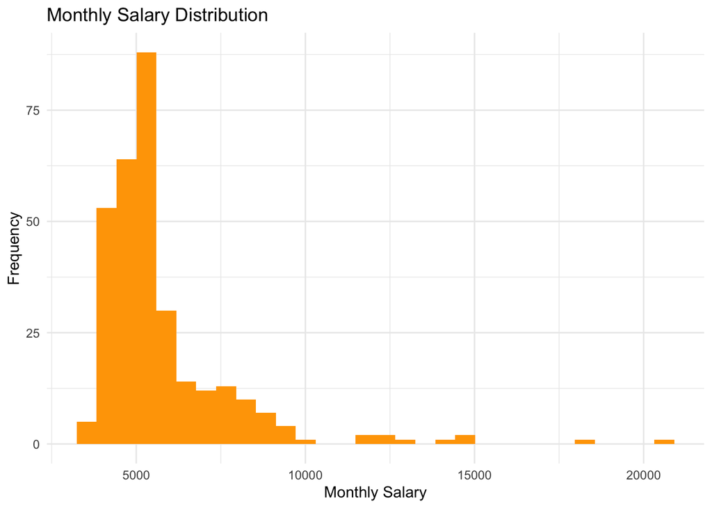

```r
# Plot the monthly salary distribution
hrdata_df %>%
  ggplot(aes(x = Monthly_Salary)) +
  geom_histogram(fill = "orange", bins = 30) +
  labs(title = "Monthly Salary Distribution", x = "Monthly Salary", y = "Frequency") +
  theme_minimal()
```

## Interpreation

- The monthly salary distribution retains the same overall shape as the original salary reported in both Questions 1 and 3 (right-skewed). The data is just scaled down by 12 as this is the number of months in a year.
- The overall distribution remains positively skewed, as was the case with the original salary distributions in Questions 1 and 3.

# Compute simple descriptive statistics for the PerfSocreID variable. In addition, produce a visualization of the frequency distribution of PerfScoreID.

## 6. Report the descriptive statistics along with the frequency distribution and provide a detailed interpretation of how you would characterize this variable.

```r
### Summary statistics
summary(hrdata_df$PerfScoreID)
```

```
##    Min. 1st Qu.  Median    Mean 3rd Qu.    Max.
##   1.000   3.000   3.000   2.977   3.000   4.000
```

```r
### Mean
mean_perfscoreid <- mean(hrdata_df$PerfScoreID, na.rm = TRUE)
print(mean_perfscoreid)
```

```
## [1] 2.977492
```

```r
#### Median
median_perfscoreid <- median(hrdata_df$PerfScoreID, na.rm = TRUE)
print(median_perfscoreid)
```

```
## [1] 3
```

```r
#### Mode
mode_perfscoreid <- function(x) {
  ux <- unique(x)
  ux[which.max(tabulate(match(x, ux)))]
}
mode_perfscoreid_value <- mode_perfscoreid(hrdata_df$PerfScoreID)
print(mode_perfscoreid_value)
```

```
## [1] 3
```

```r
### Frequency table
perfscoreid_table <- table(hrdata_df$PerfScoreID)
print(perfscoreid_table)
```

```
##
##   1   2   3   4
##  13  18 243  37
```

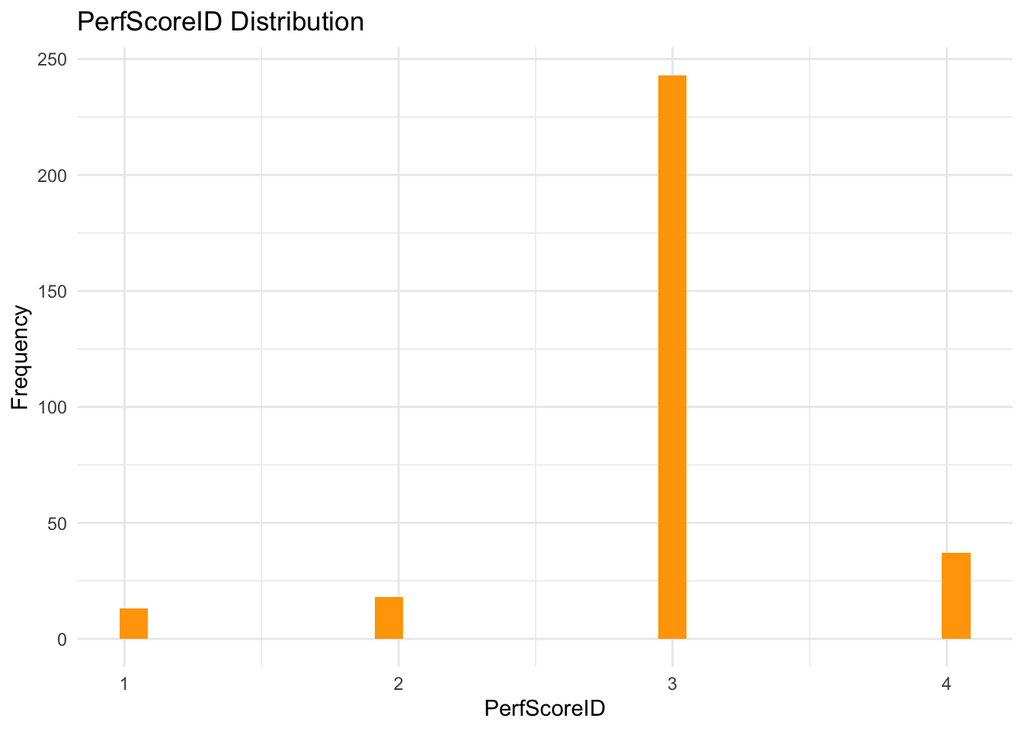

```r
#### Plot
hrdata_df %>%
  ggplot(aes(x = PerfScoreID)) +
  geom_histogram(fill = "orange", bins = 30) +
  labs(title = "PerfScoreID Distribution", x = "PerfScoreID", y = "Frequency") +
  theme_minimal()
```

### Interpretation

```r
print(paste("The mean PerfScoreID is", mean_perfscoreid))
```

```
## [1] "The mean PerfScoreID is 2.97749196141479"
```

```r
print(paste("The median PerfScoreID is", median_perfscoreid))
```

```
## [1] "The median PerfScoreID is 3"
```

```r
print(paste("The mode PerfScoreID is", mode_perfscoreid_value))
```

```
## [1] "The mode PerfScoreID is 3"
```

```r
print(paste("The frequency distribution of salaries is shown in the bar plot above."))
```

```
## [1] "The frequency distribution of salaries is shown in the bar plot above."
```

# 7. Which employee (ID number) has the largest z-score on PerfScoreID and what is the z-score for this person? Which employee (ID number) has the smallest z- score on PerfScoreID and what is the z-score for this person?

```r
# Calculate the z-scores for the PerfScoreID column
hrdata_df <- hrdata_df %>%
  mutate(perfscoreid_zscore = scale(PerfScoreID))

# Print the z-scores
print(hrdata_df$perfscoreid_zscore)
```

```
##               [,1]
##   [1,]  1.74170930
##   [2,]  1.74170930
##   [3,]  1.74170930
##   [4,]  1.74170930
##   [5,]  1.74170930
##   [6,]  1.74170930
##   [7,]  1.74170930
##   [8,]  1.74170930
##   [9,]  1.74170930
##  [10,]  1.74170930
##  [11,]  1.74170930
##  [12,]  1.74170930
##  [13,]  1.74170930
##  [14,]  1.74170930
```

[output cut: 301 more lines]

```r
# Find the index of the employee with the largest z-score
max_z_score_index <- which.max(hrdata_df$perfscoreid_zscore)
print(max_z_score_index)
```

```
## [1] 1
```

```r
# Retrieve the employee's EmpID and the corresponding z-score
max_z_score_employee <- hrdata_df[max_z_score_index, c("EmpID", "PerfScoreID")]

# Print the result
print(max_z_score_employee)
```

```
##   EmpID PerfScoreID
## 1 10001           4
```

```r
# Find the index of the employee with the smallest z-score
min_z_score_index <- which.min(hrdata_df$perfscoreid_zscore)
print(min_z_score_index)
```

```
## [1] 298
```

```r
# Retrieve the employee's EmpID and the corresponding PerfScoreID for the minimum z-score
min_z_score_employee <- hrdata_df[min_z_score_index, c("EmpID", "PerfScoreID")]

# Print the result
print(min_z_score_employee)
```

```
##     EmpID PerfScoreID
## 298 10298           1
```

# Interpretation

- The employee with the highest performance score (4) has a z-score of 1.7417, indicating that this employee’s score is significantly above the mean (by about 1.74 standard deviations).
- The employee with the lowest performance score (1) has a z-score of -3.3684, indicating that their score is far below the mean.

# 8. Compute descriptive statistics for the standardized PerfScoreID variable. Report your results and produce a frequency distribution for the standardized PerfScoreID scores. Compare this distribution to the one you produced in Question 6. Are they the same or different? Explain using both your graphical results and words.

[output not shown]

```r
# Frequency table
perfscoreid_zscore_table <- table(hrdata_df$perfscoreid_zscore)
print(perfscoreid_zscore_table)
```

```
##
##   -3.3684000667055  -1.66503027687556 0.0383395129543715   1.74170930278431
##                 13                 18                243                 37
```

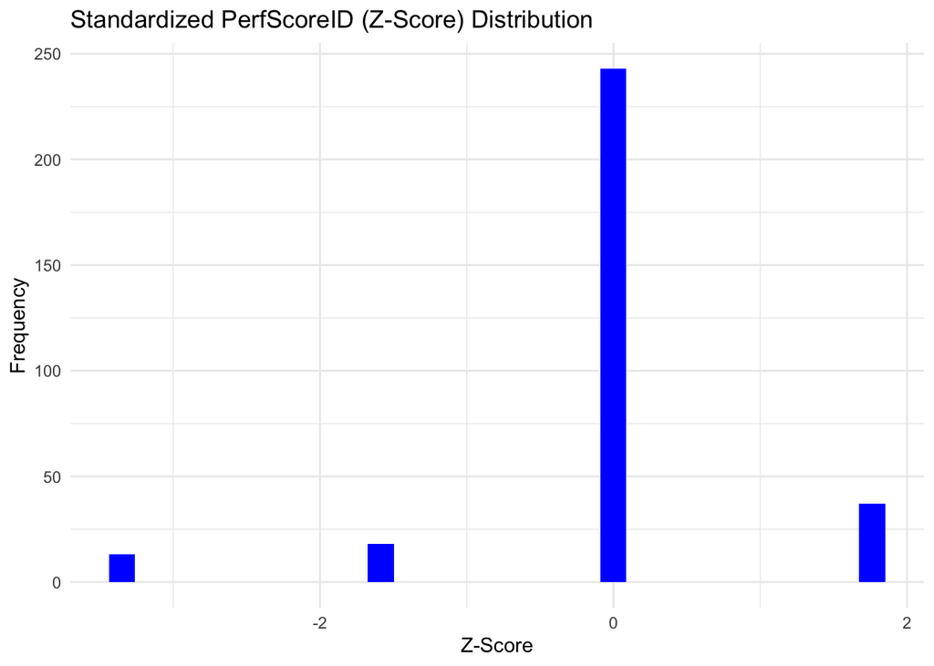

```r
# Plot the PerfScoreID z-score
hrdata_df %>%
  ggplot(aes(x = perfscoreid_zscore)) +
  geom_histogram(fill = "blue", bins = 30) +
  labs(title = "Standardized PerfScoreID (Z-Score) Distribution", x = "Z-Score", y = "Frequency") +
  theme_minimal()
```

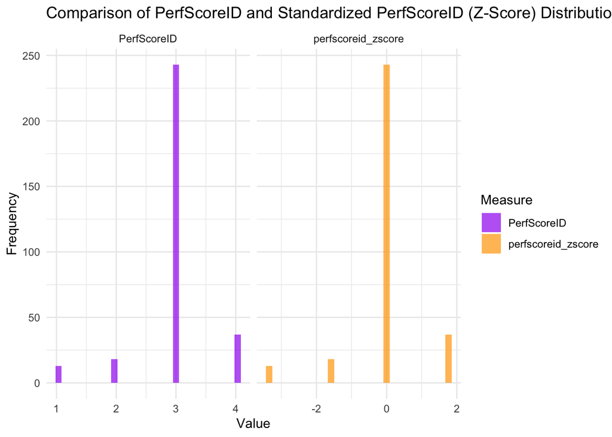

```r
# Plot of the PerfScoreID z-score and PerfScoreID
hrdata_df %>%
  pivot_longer(cols = c(PerfScoreID, perfscoreid_zscore),
               names_to = "Measure",
               values_to = "Value") %>%
  ggplot(aes(x = Value, fill = Measure)) +
  geom_histogram(bins = 30, alpha = 0.7) +
  facet_wrap(~ Measure, scales = "free_x") +   # Creates separate plots for PerfScoreID and Z-Score
  labs(title = "Comparison of PerfScoreID and Standardized PerfScoreID (Z-Score) Distributions",
       x = "Value", y = "Frequency") +
  theme_minimal() +
  scale_fill_manual(values = c("purple", "orange"))
```

# Interpretation

- The z-score distribution shows that the bulk of employees’ performance scores are close to the mean, with only a few employees having very high or very low performance scores.
- The shape of the distribution remains the same as the original PerfScoreID distribution in Question 6, but it is now centered around 0 with a standardized spread.

## 9. Square the PerfScoreID variable. Compute descriptive statistics for this new variable. Report your results and produce a frequency distribution for the squared scores. Compare this distribution to the ones you produced in Questions 1 & 3. Are they the same or different? Explain using both your graphical results and words.

```r
# Square of the PerfScoreID variable
squared_perfscoreid <- hrdata_df$PerfScoreID^2

# Summary statistics
summary(squared_perfscoreid)
```

```
##    Min. 1st Qu.  Median    Mean 3rd Qu.    Max.
##   1.000   9.000   9.000   9.209   9.000  16.000
```

```r
# Mean
mean_squared_perfscoreid <- mean(squared_perfscoreid, na.rm = TRUE)

# Median
median_squared_perfscoreid <- median(squared_perfscoreid, na.rm = TRUE)

# Mode
mode_squared_perfscoreid <- function(x) {
  ux <- unique(x)
  ux[which.max(tabulate(match(x, ux)))]
}
mode_squared_perfscoreid_value <- mode_squared_perfscoreid(squared_perfscoreid)

print(paste("Mean squared PerfScoreID:", format(round(mean_squared_perfscoreid, 2), nsmall = 2)))
```

```
## [1] "Mean squared PerfScoreID: 9.21"
```

```r
print(paste("Median squared PerfScoreID:", median_squared_perfscoreid))
```

```
## [1] "Median squared PerfScoreID: 9"
```

```r
print(paste("Mode squared PerfScoreID:", mode_squared_perfscoreid_value))
```

```
## [1] "Mode squared PerfScoreID: 9"
```

```r
# Frequency table
squared_perfscoreid_table <- table(squared_perfscoreid)
print(squared_perfscoreid_table)
```

```
## squared_perfscoreid
##   1   4   9  16
##  13  18 243  37
```

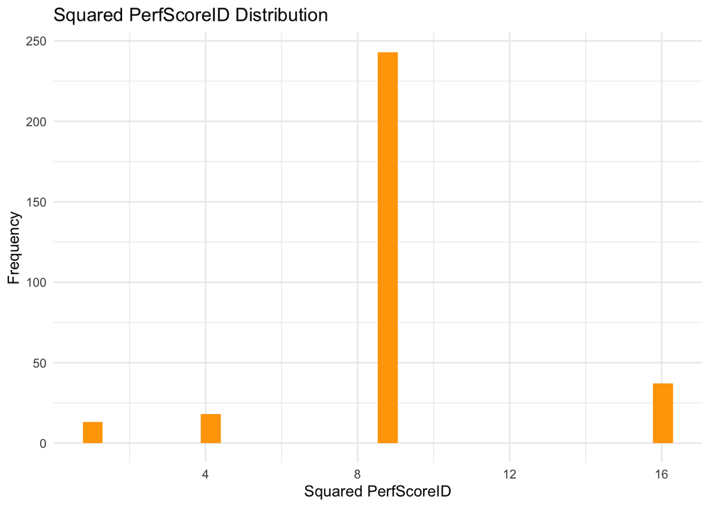

```r
# Plot the squared PerfScoreID
hrdata_df %>%
  mutate(squared_perfscoreid = PerfScoreID^2) %>%
  ggplot(aes(x = squared_perfscoreid)) +
  geom_histogram(fill = "orange", bins = 30) +
  labs(title = "Squared PerfScoreID Distribution", x = "Squared PerfScoreID", y = "Frequency") +
  theme_minimal()
```

# Interpretation

- The squared transformation increases differences in scores, especially for employees with extreme performance scores.
- The median and mode remain 9, as most employees still have a performance score of 3 (which squares to 9).
- The shape of the distribution is different from the results from Questions 1 and 3 as the squared values accentuate the differences between scores resulting in a more spread-out distribution although still unimodal.